# Discrete Race + Two Low-Threshold

William Hopper

Oct 07, 2019

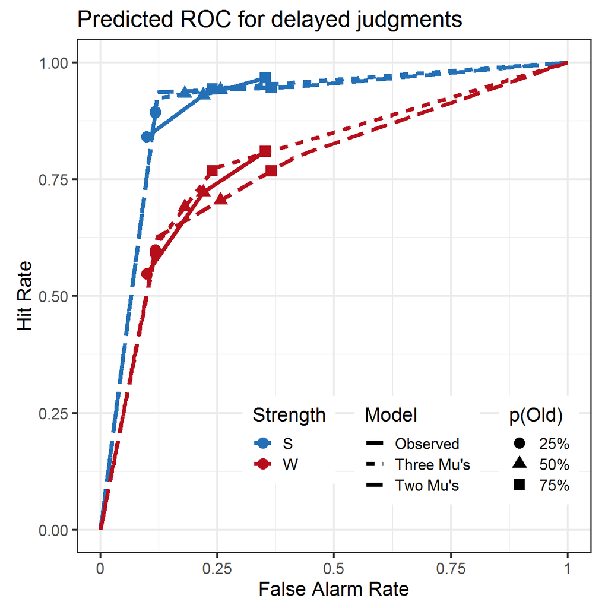

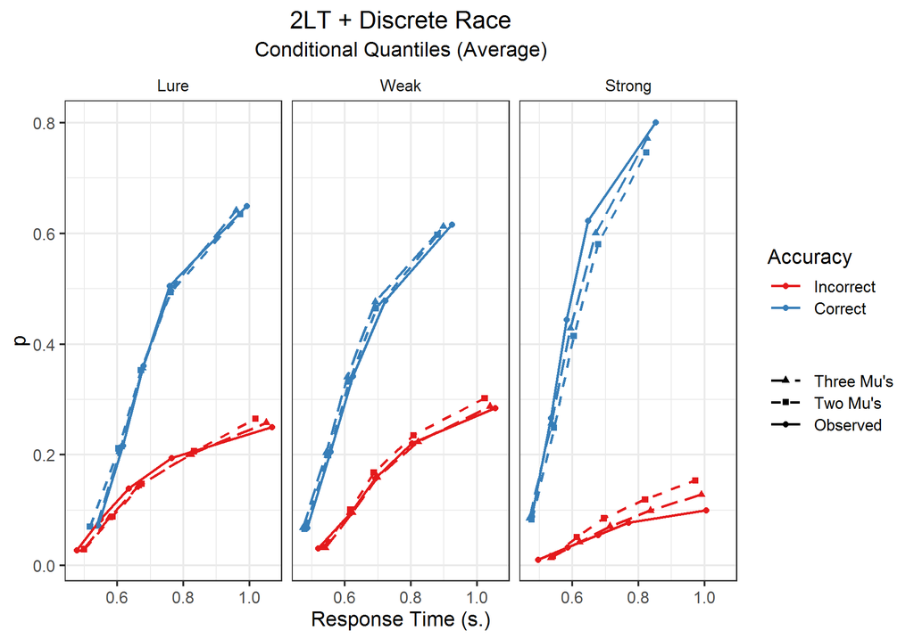

model

Subject

DO<sub>L</sub>

FD<sub>L</sub>

DO<sub>W</sub>

FD<sub>W</sub>

DO<sub>S</sub>

FD<sub>S</sub>

b

b<sub>C</sub>

b<sub>N</sub>

b<sub>L</sub>

µ<sub>D</sub>

µ<sub>G</sub>

µ<sub>DN</sub>

σ

v

G<sup>2</sup>

yoked

101

0.176

0.548

0.644

0.232

0.939

0.051

0.695

1.203

0.955

0.581

0.430

0.544

0.052

0.185

115.214

102

0.000

0.000

0.421

0.000

0.744

0.000

0.090

-0.249

-0.431

-0.569

0.605

0.493

0.074

0.488

71.180

103

0.253

0.329

0.790

0.147

0.969

0.000

0.779

1.236

1.018

0.130

0.464

0.587

0.057

0.080

116.000

104

0.077

0.120

0.613

0.143

0.830

0.093

0.592

1.068

0.358

-0.055

0.532

1.585

0.045

0.249

160.157

105

0.139

0.016

0.238

0.334

0.921

0.000

0.069

1.274

-0.597

-0.907

0.537

0.345

0.067

0.235

31.855

106

0.140

0.332

0.698

0.129

0.972

0.000

0.688

1.123

0.841

0.525

0.456

0.616

0.088

0.329

229.147

107

0.084

0.278

0.600

0.243

0.939

0.000

0.682

1.199

0.522

0.075

0.563

0.721

0.070

0.271

88.567

108

0.048

0.071

0.758

0.060

0.983

0.000

0.664

1.010

0.954

-0.047

0.490

0.859

0.042

0.090

126.162

109

0.054

0.658

0.856

0.119

0.997

0.003

0.918

1.041

1.021

0.906

0.471

0.612

0.028

0.172

288.911

110

0.070

0.000

0.425

0.147

0.938

0.000

0.394

1.106

-0.090

-0.147

0.525

0.471

0.079

0.224

111.086

111

0.156

0.654

0.657

0.289

0.960

0.000

0.843

1.115

0.973

0.580

0.478

0.598

0.028

0.117

145.086

112

0.238

0.529

0.716

0.222

0.971

0.018

0.682

1.032

0.982

0.923

0.516

0.689

0.033

0.268

151.341

113

0.028

0.047

0.665

0.095

0.978

0.000

0.760

1.000

0.000

-0.036

0.599

1.141

0.045

0.136

84.666

114

0.251

0.560

0.692

0.244

0.965

0.000

0.727

1.457

1.130

0.524

0.430

0.561

0.083

0.201

92.005

unyoked

101

0.106

0.009

0.574

0.078

0.938

0.009

0.474

1.121

-0.092

-0.309

0.420

0.475

0.540

0.056

0.281

83.369

102

0.000

0.031

0.403

0.069

0.775

0.000

0.188

-0.223

-0.404

-0.538

0.551

0.481

0.670

0.050

0.474

53.072

103

0.246

0.129

0.749

0.077

0.931

0.000

0.719

1.205

0.844

-0.305

0.459

0.676

0.502

0.051

0.068

79.199

104

0.077

0.116

0.614

0.139

0.828

0.095

0.583

1.066

0.340

-0.061

0.507

1.592

0.555

0.030

0.249

115.908

105

0.137

0.018

0.265

0.316

0.873

0.054

0.076

1.252

-0.595

-0.905

0.436

0.351

0.545

0.073

0.245

24.136

106

0.162

0.075

0.667

0.031

0.925

0.008

0.464

1.106

0.471

-0.125

0.485

1.522

0.550

0.094

0.177

92.667

107

0.077

0.186

0.576

0.217

0.932

0.000

0.635

1.182

0.310

-0.115

0.542

0.715

0.596

0.070

0.289

71.851

108

0.048

0.069

0.756

0.059

0.983

0.000

0.646

1.009

0.943

-0.050

0.487

0.871

0.497

0.043

0.089

121.286

109

0.061

0.122

0.818

0.042

0.994

0.000

0.898

1.034

1.013

0.498

0.479

0.931

0.563

0.035

0.122

100.952

110

0.143

0.000

0.527

0.370

0.936

0.064

0.565

1.203

0.895

0.706

0.451

0.499

0.573

0.077

0.195

66.626

111

0.160

0.303

0.619

0.209

0.942

0.000

0.803

1.096

0.924

0.162

0.482

0.673

0.539

0.031

0.096

129.863

112

0.258

0.128

0.693

0.068

0.967

0.000

0.557

1.032

1.015

0.630

0.544

1.058

0.641

0.060

0.170

47.541

113

0.020

0.102

0.696

0.264

0.995

0.000

0.778

1.000

0.532

0.547

0.563

0.671

0.586

0.048

0.248

265.427

114

0.199

0.420

0.598

0.333

0.901

0.063

0.641

1.377

0.952

0.296

0.420

0.538

0.541

0.088

0.214

95.262

- Download Scaled Parameters
- Download Raw Parameters
- Download GOF Statistics

## Individual Subjects

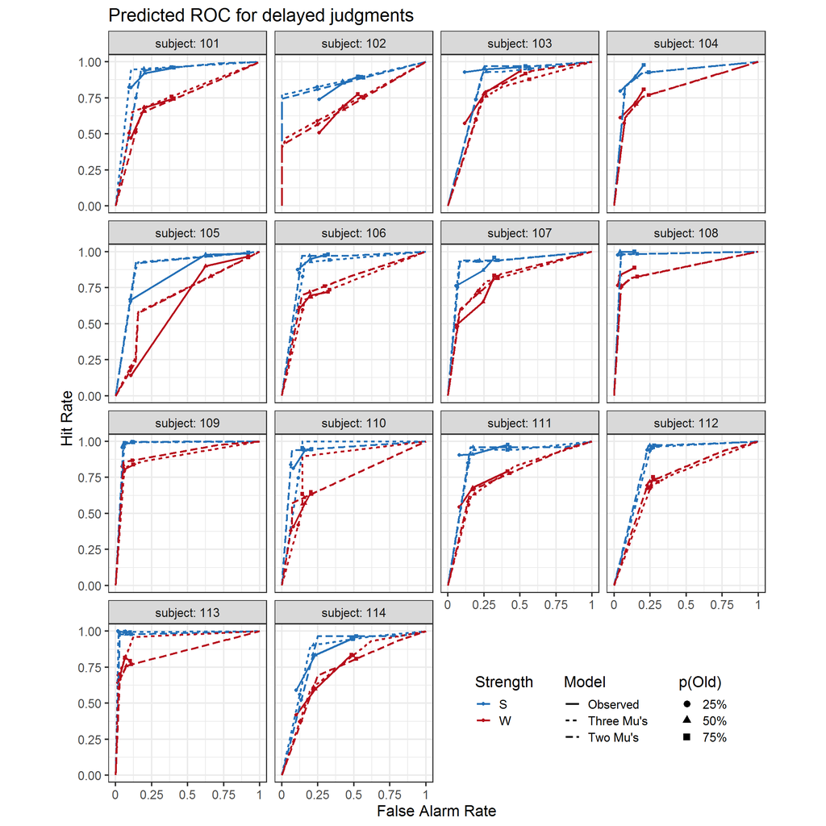

### Subject 101

model

DO<sub>L</sub>

FD<sub>L</sub>

DO<sub>W</sub>

FD<sub>W</sub>

DO<sub>S</sub>

FD<sub>S</sub>

b

b<sub>C</sub>

b<sub>N</sub>

b<sub>L</sub>

µ<sub>D</sub>

µ<sub>G</sub>

µ<sub>DN</sub>

s

v

yoked

0.176

0.548

0.644

0.232

0.939

0.051

0.695

1.203

0.955

0.581

0.43

0.544

0.052

0.185

unyoked

0.106

0.009

0.574

0.078

0.938

0.009

0.474

1.121

-0.092

-0.309

0.42

0.475

0.54

0.056

0.281

| model | LL | G<sup>2</sup> | df | p(X<sup>2</sup>) | fevals | gevals | niter | convcode |
| --- | --- | --- | --- | --- | --- | --- | --- | --- |
| yoked | -157.937 | 115.214 | 28 | 0 | 111 | 1164 | 73 | 0 |
| unyoked | -142.014 | 83.369 | 27 | 0 | 127 | 1507 | 86 | 0 |

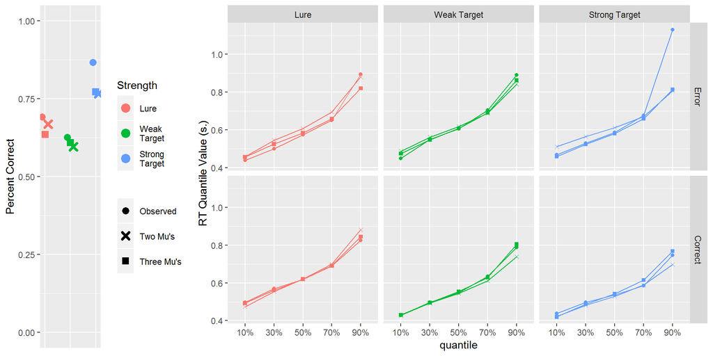

### Subject 102

model

DO<sub>L</sub>

FD<sub>L</sub>

DO<sub>W</sub>

FD<sub>W</sub>

DO<sub>S</sub>

FD<sub>S</sub>

b

b<sub>C</sub>

b<sub>N</sub>

b<sub>L</sub>

µ<sub>D</sub>

µ<sub>G</sub>

µ<sub>DN</sub>

s

v

yoked

0

0.000

0.421

0.000

0.744

0

0.090

-0.249

-0.431

-0.569

0.605

0.493

0.074

0.488

unyoked

0

0.031

0.403

0.069

0.775

0

0.188

-0.223

-0.404

-0.538

0.551

0.481

0.67

0.050

0.474

| model | LL | G<sup>2</sup> | df | p(X<sup>2</sup>) | fevals | gevals | niter | convcode |
| --- | --- | --- | --- | --- | --- | --- | --- | --- |
| yoked | -136.019 | 71.180 | 28 | 0.000 | 131 | 1639 | 95 | 0 |
| unyoked | -126.965 | 53.072 | 27 | 0.002 | 134 | 1825 | 96 | 0 |

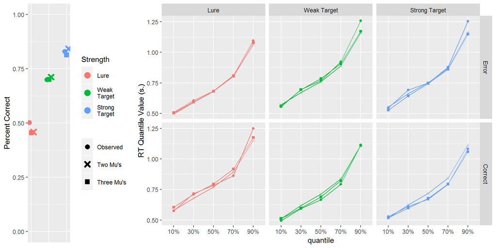

### Subject 103

model

DO<sub>L</sub>

FD<sub>L</sub>

DO<sub>W</sub>

FD<sub>W</sub>

DO<sub>S</sub>

FD<sub>S</sub>

b

b<sub>C</sub>

b<sub>N</sub>

b<sub>L</sub>

µ<sub>D</sub>

µ<sub>G</sub>

µ<sub>DN</sub>

s

v

yoked

0.253

0.329

0.790

0.147

0.969

0

0.779

1.236

1.018

0.130

0.464

0.587

0.057

0.080

unyoked

0.246

0.129

0.749

0.077

0.931

0

0.719

1.205

0.844

-0.305

0.459

0.676

0.502

0.051

0.068

| model | LL | G<sup>2</sup> | df | p(X<sup>2</sup>) | fevals | gevals | niter | convcode |
| --- | --- | --- | --- | --- | --- | --- | --- | --- |
| yoked | -155.528 | 116.000 | 28 | 0 | 144 | 1510 | 87 | 0 |
| unyoked | -137.128 | 79.199 | 27 | 0 | 145 | 1923 | 105 | 0 |

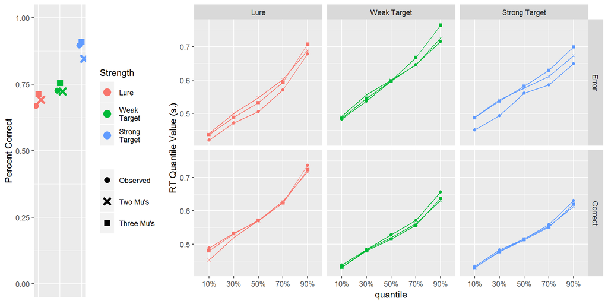

### Subject 104

model

DO<sub>L</sub>

FD<sub>L</sub>

DO<sub>W</sub>

FD<sub>W</sub>

DO<sub>S</sub>

FD<sub>S</sub>

b

b<sub>C</sub>

b<sub>N</sub>

b<sub>L</sub>

µ<sub>D</sub>

µ<sub>G</sub>

µ<sub>DN</sub>

s

v

yoked

0.077

0.120

0.613

0.143

0.830

0.093

0.592

1.068

0.358

-0.055

0.532

1.585

0.045

0.249

unyoked

0.077

0.116

0.614

0.139

0.828

0.095

0.583

1.066

0.340

-0.061

0.507

1.592

0.555

0.030

0.249

| model | LL | G<sup>2</sup> | df | p(X<sup>2</sup>) | fevals | gevals | niter | convcode |
| --- | --- | --- | --- | --- | --- | --- | --- | --- |
| yoked | -177.629 | 160.157 | 28 | 0 | 85 | 1001 | 58 | 0 |
| unyoked | -155.505 | 115.908 | 27 | 0 | 87 | 1143 | 65 | 0 |

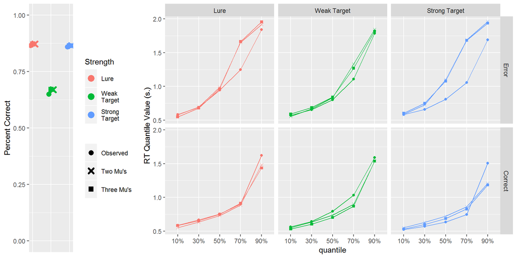

### Subject 105

model

DO<sub>L</sub>

FD<sub>L</sub>

DO<sub>W</sub>

FD<sub>W</sub>

DO<sub>S</sub>

FD<sub>S</sub>

b

b<sub>C</sub>

b<sub>N</sub>

b<sub>L</sub>

µ<sub>D</sub>

µ<sub>G</sub>

µ<sub>DN</sub>

s

v

yoked

0.139

0.016

0.238

0.334

0.921

0.000

0.069

1.274

-0.597

-0.907

0.537

0.345

0.067

0.235

unyoked

0.137

0.018

0.265

0.316

0.873

0.054

0.076

1.252

-0.595

-0.905

0.436

0.351

0.545

0.073

0.245

| model | LL | G<sup>2</sup> | df | p(X<sup>2</sup>) | fevals | gevals | niter | convcode |
| --- | --- | --- | --- | --- | --- | --- | --- | --- |
| yoked | -109.697 | 31.855 | 28 | 0.280 | 112 | 1564 | 87 | 0 |
| unyoked | -105.838 | 24.136 | 27 | 0.623 | 142 | 1775 | 104 | 0 |

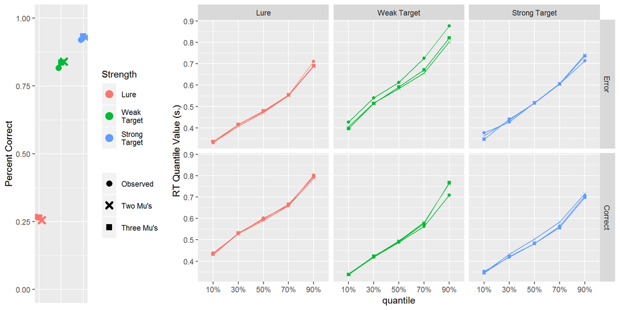

### Subject 106

model

DO<sub>L</sub>

FD<sub>L</sub>

DO<sub>W</sub>

FD<sub>W</sub>

DO<sub>S</sub>

FD<sub>S</sub>

b

b<sub>C</sub>

b<sub>N</sub>

b<sub>L</sub>

µ<sub>D</sub>

µ<sub>G</sub>

µ<sub>DN</sub>

s

v

yoked

0.140

0.332

0.698

0.129

0.972

0.000

0.688

1.123

0.841

0.525

0.456

0.616

0.088

0.329

unyoked

0.162

0.075

0.667

0.031

0.925

0.008

0.464

1.106

0.471

-0.125

0.485

1.522

0.55

0.094

0.177

| model | LL | G<sup>2</sup> | df | p(X<sup>2</sup>) | fevals | gevals | niter | convcode |
| --- | --- | --- | --- | --- | --- | --- | --- | --- |
| yoked | -212.972 | 229.147 | 28 | 0 | 113 | 1450 | 81 | 0 |
| unyoked | -144.733 | 92.667 | 27 | 0 | 93 | 1215 | 71 | 0 |

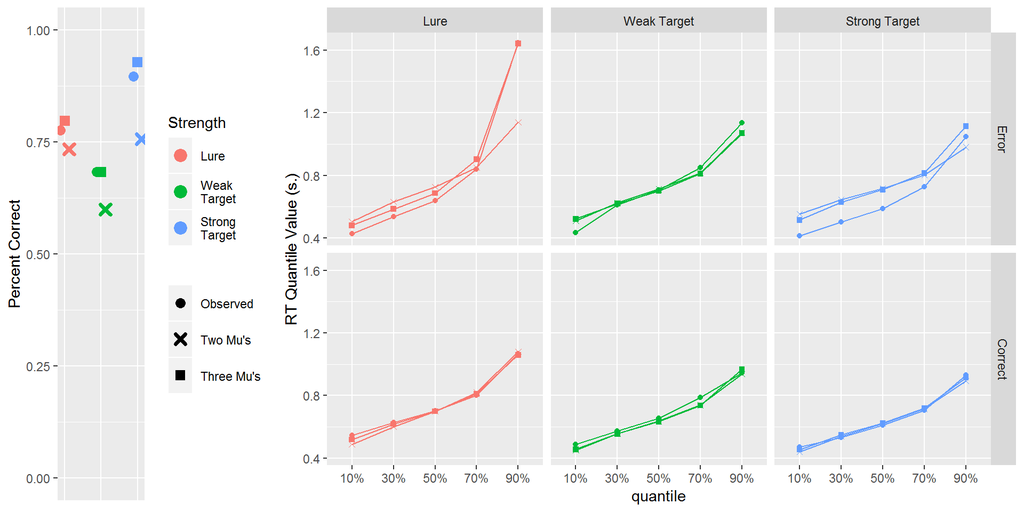

### Subject 107

model

DO<sub>L</sub>

FD<sub>L</sub>

DO<sub>W</sub>

FD<sub>W</sub>

DO<sub>S</sub>

FD<sub>S</sub>

b

b<sub>C</sub>

b<sub>N</sub>

b<sub>L</sub>

µ<sub>D</sub>

µ<sub>G</sub>

µ<sub>DN</sub>

s

v

yoked

0.084

0.278

0.600

0.243

0.939

0

0.682

1.199

0.522

0.075

0.563

0.721

0.07

0.271

unyoked

0.077

0.186

0.576

0.217

0.932

0

0.635

1.182

0.310

-0.115

0.542

0.715

0.596

0.07

0.289

| model | LL | G<sup>2</sup> | df | p(X<sup>2</sup>) | fevals | gevals | niter | convcode |
| --- | --- | --- | --- | --- | --- | --- | --- | --- |
| yoked | -143.609 | 88.567 | 28 | 0 | 105 | 1348 | 75 | 0 |
| unyoked | -135.251 | 71.851 | 27 | 0 | 104 | 1624 | 86 | 0 |

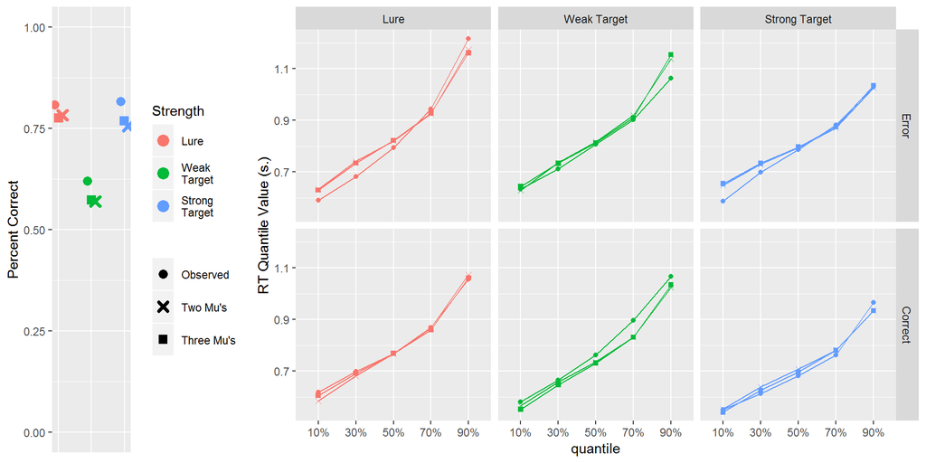

### Subject 108

model

DO<sub>L</sub>

FD<sub>L</sub>

DO<sub>W</sub>

FD<sub>W</sub>

DO<sub>S</sub>

FD<sub>S</sub>

b

b<sub>C</sub>

b<sub>N</sub>

b<sub>L</sub>

µ<sub>D</sub>

µ<sub>G</sub>

µ<sub>DN</sub>

s

v

yoked

0.048

0.071

0.758

0.060

0.983

0

0.664

1.010

0.954

-0.047

0.490

0.859

0.042

0.090

unyoked

0.048

0.069

0.756

0.059

0.983

0

0.646

1.009

0.943

-0.050

0.487

0.871

0.497

0.043

0.089

| model | LL | G<sup>2</sup> | df | p(X<sup>2</sup>) | fevals | gevals | niter | convcode |
| --- | --- | --- | --- | --- | --- | --- | --- | --- |
| yoked | -149.260 | 126.162 | 28 | 0 | 112 | 1264 | 75 | 0 |
| unyoked | -146.822 | 121.286 | 27 | 0 | 164 | 1973 | 115 | 0 |

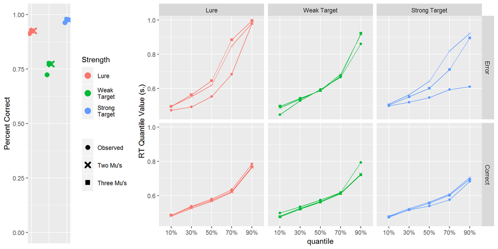

### Subject 109

model

DO<sub>L</sub>

FD<sub>L</sub>

DO<sub>W</sub>

FD<sub>W</sub>

DO<sub>S</sub>

FD<sub>S</sub>

b

b<sub>C</sub>

b<sub>N</sub>

b<sub>L</sub>

µ<sub>D</sub>

µ<sub>G</sub>

µ<sub>DN</sub>

s

v

yoked

0.054

0.658

0.856

0.119

0.997

0.003

0.918

1.041

1.021

0.906

0.471

0.612

0.028

0.172

unyoked

0.061

0.122

0.818

0.042

0.994

0.000

0.898

1.034

1.013

0.498

0.479

0.931

0.563

0.035

0.122

| model | LL | G<sup>2</sup> | df | p(X<sup>2</sup>) | fevals | gevals | niter | convcode |
| --- | --- | --- | --- | --- | --- | --- | --- | --- |
| yoked | -229.016 | 288.911 | 28 | 0 | 142 | 1945 | 109 | 0 |
| unyoked | -135.037 | 100.952 | 27 | 0 | 160 | 1931 | 108 | 0 |

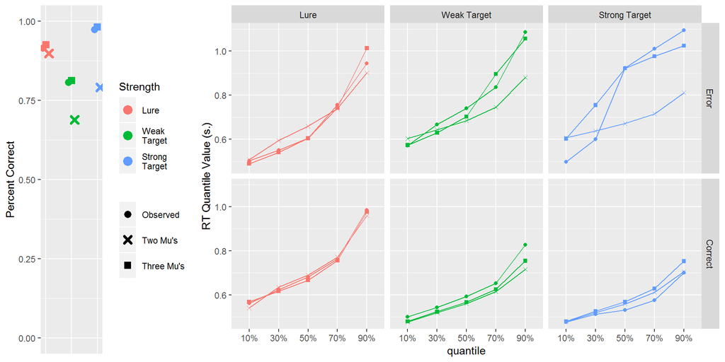

### Subject 110

model

DO<sub>L</sub>

FD<sub>L</sub>

DO<sub>W</sub>

FD<sub>W</sub>

DO<sub>S</sub>

FD<sub>S</sub>

b

b<sub>C</sub>

b<sub>N</sub>

b<sub>L</sub>

µ<sub>D</sub>

µ<sub>G</sub>

µ<sub>DN</sub>

s

v

yoked

0.070

0

0.425

0.147

0.938

0.000

0.394

1.106

-0.090

-0.147

0.525

0.471

0.079

0.224

unyoked

0.143

0

0.527

0.370

0.936

0.064

0.565

1.203

0.895

0.706

0.451

0.499

0.573

0.077

0.195

| model | LL | G<sup>2</sup> | df | p(X<sup>2</sup>) | fevals | gevals | niter | convcode |
| --- | --- | --- | --- | --- | --- | --- | --- | --- |
| yoked | -156.865 | 111.086 | 28 | 0 | 125 | 1481 | 84 | 0 |
| unyoked | -134.635 | 66.626 | 27 | 0 | 133 | 2003 | 105 | 0 |

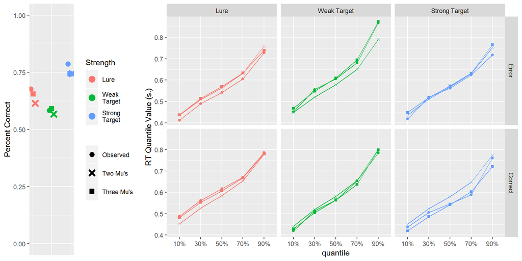

### Subject 111

model

DO<sub>L</sub>

FD<sub>L</sub>

DO<sub>W</sub>

FD<sub>W</sub>

DO<sub>S</sub>

FD<sub>S</sub>

b

b<sub>C</sub>

b<sub>N</sub>

b<sub>L</sub>

µ<sub>D</sub>

µ<sub>G</sub>

µ<sub>DN</sub>

s

v

yoked

0.156

0.654

0.657

0.289

0.960

0

0.843

1.115

0.973

0.580

0.478

0.598

0.028

0.117

unyoked

0.160

0.303

0.619

0.209

0.942

0

0.803

1.096

0.924

0.162

0.482

0.673

0.539

0.031

0.096

| model | LL | G<sup>2</sup> | df | p(X<sup>2</sup>) | fevals | gevals | niter | convcode |
| --- | --- | --- | --- | --- | --- | --- | --- | --- |
| yoked | -170.395 | 145.086 | 28 | 0 | 121 | 1537 | 89 | 0 |
| unyoked | -162.784 | 129.863 | 27 | 0 | 150 | 1890 | 106 | 0 |

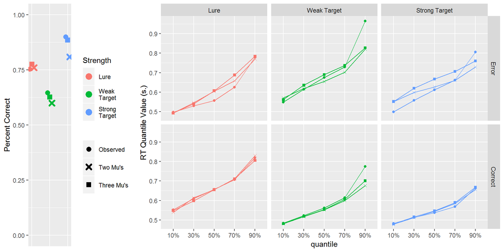

### Subject 112

model

DO<sub>L</sub>

FD<sub>L</sub>

DO<sub>W</sub>

FD<sub>W</sub>

DO<sub>S</sub>

FD<sub>S</sub>

b

b<sub>C</sub>

b<sub>N</sub>

b<sub>L</sub>

µ<sub>D</sub>

µ<sub>G</sub>

µ<sub>DN</sub>

s

v

yoked

0.238

0.529

0.716

0.222

0.971

0.018

0.682

1.032

0.982

0.923

0.516

0.689

0.033

0.268

unyoked

0.258

0.128

0.693

0.068

0.967

0.000

0.557

1.032

1.015

0.630

0.544

1.058

0.641

0.060

0.170

| model | LL | G<sup>2</sup> | df | p(X<sup>2</sup>) | fevals | gevals | niter | convcode |
| --- | --- | --- | --- | --- | --- | --- | --- | --- |
| yoked | -170.618 | 151.341 | 28 | 0.000 | 108 | 1300 | 82 | 0 |
| unyoked | -118.718 | 47.541 | 27 | 0.009 | 112 | 1683 | 92 | 0 |

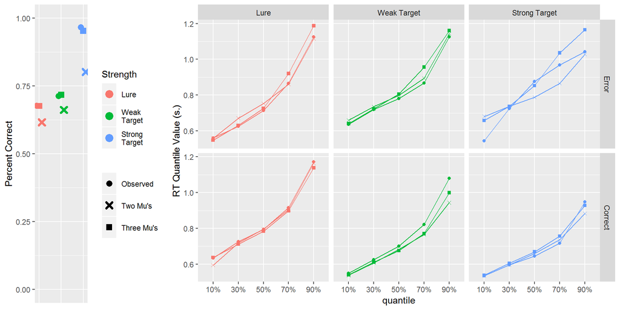

### Subject 113

model

DO<sub>L</sub>

FD<sub>L</sub>

DO<sub>W</sub>

FD<sub>W</sub>

DO<sub>S</sub>

FD<sub>S</sub>

b

b<sub>C</sub>

b<sub>N</sub>

b<sub>L</sub>

µ<sub>D</sub>

µ<sub>G</sub>

µ<sub>DN</sub>

s

v

yoked

0.028

0.047

0.665

0.095

0.978

0

0.760

1

0.000

-0.036

0.599

1.141

0.045

0.136

unyoked

0.020

0.102

0.696

0.264

0.995

0

0.778

1

0.532

0.547

0.563

0.671

0.586

0.048

0.248

| model | LL | G<sup>2</sup> | df | p(X<sup>2</sup>) | fevals | gevals | niter | convcode |
| --- | --- | --- | --- | --- | --- | --- | --- | --- |
| yoked | -129.869 | 84.666 | 28 | 0 | 200 | 1928 | 108 | 1 |
| unyoked | -220.250 | 265.427 | 27 | 0 | 92 | 724 | 38 | 1 |

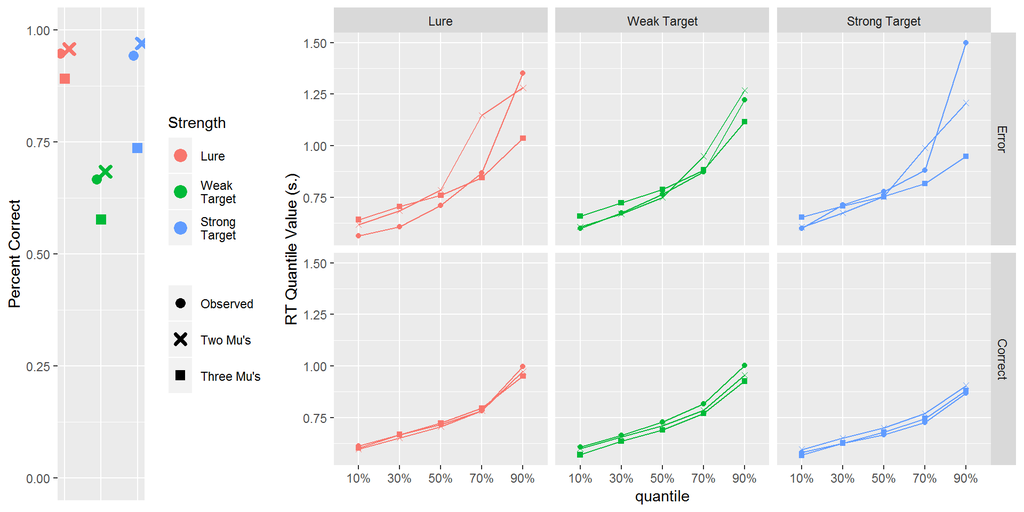

### Subject 114

model

DO<sub>L</sub>

FD<sub>L</sub>

DO<sub>W</sub>

FD<sub>W</sub>

DO<sub>S</sub>

FD<sub>S</sub>

b

b<sub>C</sub>

b<sub>N</sub>

b<sub>L</sub>

µ<sub>D</sub>

µ<sub>G</sub>

µ<sub>DN</sub>

s

v

yoked

0.251

0.56

0.692

0.244

0.965

0.000

0.727

1.457

1.130

0.524

0.43

0.561

0.083

0.201

unyoked

0.199

0.42

0.598

0.333

0.901

0.063

0.641

1.377

0.952

0.296

0.42

0.538

0.541

0.088

0.214

| model | LL | G<sup>2</sup> | df | p(X<sup>2</sup>) | fevals | gevals | niter | convcode |
| --- | --- | --- | --- | --- | --- | --- | --- | --- |
| yoked | -147.782 | 92.005 | 28 | 0 | 118 | 1472 | 85 | 0 |
| unyoked | -149.411 | 95.262 | 27 | 0 | 93 | 1231 | 71 | 0 |

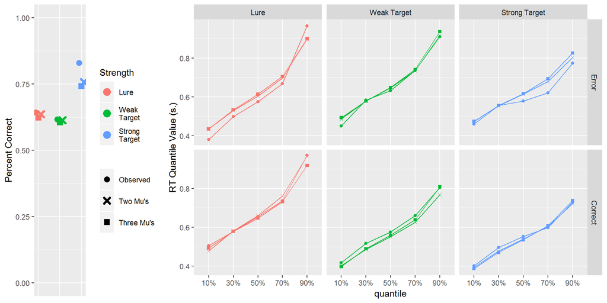